# Market Basket Analysis

To illustrate the process of market basket analysis, we will begin with a simple dataset. Next, we will extend these ideas to a larger dataset.

## Small Data

This is a toy dataset consisting of a set of nine transactions. Each row represents items purchased on a single visit to a supermarket. Note that specific items as well as number of items vary across visits.

```python
import pandas as pd
from mlxtend.preprocessing import TransactionEncoder
from mlxtend.frequent_patterns import apriori, fpmax, fpgrowth
import matplotlib.pyplot as plt

dataset = [['beer', 'diapers', 'bread'],
           ['diapers', 'eggs'],
           ['diapers', 'beer'],
           ['beer', 'diapers', 'eggs'],
           ['beer', 'diapers'],
           ['diapers', 'milk'],
           ['milk', 'bread'],
           ['diapers', 'beer','milk','bread'],
           ['beer', 'diapers','milk'],]
```

To use it for analysis, the data needs to be transformed into a rectangular data structure.

```python
te = TransactionEncoder()
te_ary = te.fit(dataset).transform(dataset)
df = pd.DataFrame(te_ary, columns=te.columns_)
df
```

|  | beer | bread | diapers | eggs | milk |
| --- | --- | --- | --- | --- | --- |
| 0 | True | True | True | False | False |
| 1 | False | False | True | True | False |
| 2 | True | False | True | False | False |
| 3 | True | False | True | True | False |
| 4 | True | False | True | False | False |
| 5 | False | False | True | False | True |
| 6 | False | True | False | False | True |
| 7 | True | True | True | False | True |
| 8 | True | False | True | False | True |

## Explore Data

Number of transactions

```python
df.shape[0]
```

```
9
```

Number of items

```python
df.shape[1]
```

```
5
```

Most frequently purchased items

```python
df.apply('sum',axis=0).sort_values(ascending=False)
```

```
diapers    8
beer       6
milk       4
bread      3
eggs       2
dtype: int64
```

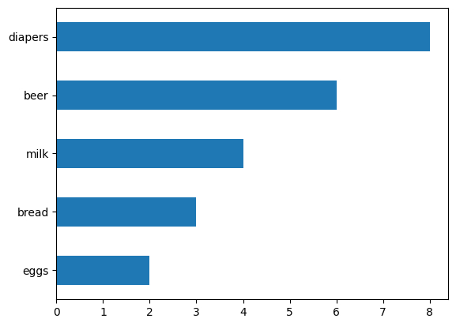

```python
df.apply('sum',axis=0).sort_values(ascending=True).plot.barh()
plt.show()
```

## Analysis

#### Frequency or Counts

```python
items = df.columns.tolist()
n_items = len(items)
count_table = pd.DataFrame(index=items, columns=items)

for i, item1 in enumerate(items):
    for j, item2 in enumerate(items):
        # Count of transactions containing both items
        count_table.loc[item1, item2] = (df[item1] & df[item2]).sum()
count_table
```

|  | beer | bread | diapers | eggs | milk |
| --- | --- | --- | --- | --- | --- |
| beer | 6 | 2 | 6 | 1 | 2 |
| bread | 2 | 3 | 2 | 0 | 2 |
| diapers | 6 | 2 | 8 | 2 | 3 |
| eggs | 1 | 0 | 2 | 2 | 0 |
| milk | 2 | 2 | 3 | 0 | 4 |

#### Support

Prevalence of an item set

```python
support_table = pd.DataFrame(index=items, columns=items)

for i, item1 in enumerate(items):
    for j, item2 in enumerate(items):
        # Support (proportion of transactions containing both items)
        support_table.loc[item1, item2] = (df[item1] & df[item2]).sum() / len(df)
support_table.round(3)
```

|  | beer | bread | diapers | eggs | milk |
| --- | --- | --- | --- | --- | --- |
| beer | 0.666667 | 0.222222 | 0.666667 | 0.111111 | 0.222222 |
| bread | 0.222222 | 0.333333 | 0.222222 | 0.0 | 0.222222 |
| diapers | 0.666667 | 0.222222 | 0.888889 | 0.222222 | 0.333333 |
| eggs | 0.111111 | 0.0 | 0.222222 | 0.222222 | 0.0 |
| milk | 0.222222 | 0.222222 | 0.333333 | 0.0 | 0.444444 |

#### Confidence

Confidence is the conditional probability of item B being chosen, assuming item A has already been picked. Unlike Support, Confidence is directional.

```python
import numpy as np
confidence_table = pd.DataFrame(index=items, columns=items)
for i, item1 in enumerate(items):
    for j, item2 in enumerate(items):
        if i != j:  # Don't compute confidence for same item
            # Support of antecedent (item1)
            support_antecedent = df[item1].sum() / len(df)
            # Support of both items together
            support_both = (df[item1] & df[item2]).sum() / len(df)
            # Confidence = Support(both) / Support(antecedent)
            if support_antecedent > 0:
                confidence = support_both / support_antecedent
            else:
                confidence = 0
            confidence_table.loc[item1, item2] = confidence
        else:
            # Confidence of item to itself is undefined
            confidence_table.loc[item1, item2] = np.nan

confidence_table.round(3)
```

|  | beer | bread | diapers | eggs | milk |
| --- | --- | --- | --- | --- | --- |
| beer | NaN | 0.333333 | 1.0 | 0.166667 | 0.333333 |
| bread | 0.666667 | NaN | 0.666667 | 0.0 | 0.666667 |
| diapers | 0.75 | 0.25 | NaN | 0.25 | 0.375 |
| eggs | 0.5 | 0.0 | 1.0 | NaN | 0.0 |
| milk | 0.5 | 0.5 | 0.75 | 0.0 | NaN |

#### Lift

Strength of association. Lift of 1 indicates independence, i.e., no association

```python
lift_table = pd.DataFrame(index=items, columns=items)

for i, item1 in enumerate(items):
    for j, item2 in enumerate(items):
        # Lift (strength of association)
        support_both = (df[item1] & df[item2]).sum() / len(df)
        support_item1 = df[item1].sum() / len(df)
        support_item2 = df[item2].sum() / len(df)
        if support_item1 * support_item2 > 0:
            lift_table.loc[item1, item2] = support_both / (support_item1 * support_item2)
        else:
            lift_table.loc[item1, item2] = 0

lift_table.round(3)
```

|  | beer | bread | diapers | eggs | milk |
| --- | --- | --- | --- | --- | --- |
| beer | 1.5 | 1.0 | 1.125 | 0.75 | 0.75 |
| bread | 1.0 | 3.0 | 0.75 | 0.0 | 1.5 |
| diapers | 1.125 | 0.75 | 1.125 | 1.125 | 0.84375 |
| eggs | 0.75 | 0.0 | 1.125 | 4.5 | 0.0 |
| milk | 0.75 | 1.5 | 0.84375 | 0.0 | 2.25 |

## Generate Rules

Frequent itemsets are an ingredient for generate_rules(). Dataframes of frequent itemsets as produced by the apriori, fpgrowth, or fpmax functions in mlxtend.association. We will utilize apriori.

### Frequent Itemsets

```python
frequent_itemsets = apriori(df, min_support=0.001, use_colnames=True)
frequent_itemsets
```

|  | support | itemsets |
| --- | --- | --- |
| 0 | 0.666667 | (beer) |
| 1 | 0.333333 | (bread) |
| 2 | 0.888889 | (diapers) |
| 3 | 0.222222 | (eggs) |
| 4 | 0.444444 | (milk) |
| 5 | 0.222222 | (bread, beer) |
| 6 | 0.666667 | (diapers, beer) |
| 7 | 0.111111 | (eggs, beer) |
| 8 | 0.222222 | (beer, milk) |
| 9 | 0.222222 | (diapers, bread) |
| 10 | 0.222222 | (bread, milk) |
| 11 | 0.222222 | (diapers, eggs) |
| 12 | 0.333333 | (diapers, milk) |
| 13 | 0.222222 | (diapers, bread, beer) |
| 14 | 0.111111 | (bread, beer, milk) |
| 15 | 0.111111 | (diapers, eggs, beer) |
| 16 | 0.222222 | (diapers, beer, milk) |
| 17 | 0.111111 | (diapers, bread, milk) |
| 18 | 0.111111 | (diapers, bread, beer, milk) |

```python
fpmax(df, min_support=0.001, use_colnames=True)
```

|  | support | itemsets |
| --- | --- | --- |
| 0 | 0.111111 | (diapers, eggs, beer) |
| 1 | 0.111111 | (diapers, bread, beer, milk) |

```python
fpgrowth(df, min_support=0.001, use_colnames=True)
```

|  | support | itemsets |
| --- | --- | --- |
| 0 | 0.888889 | (diapers) |
| 1 | 0.666667 | (beer) |
| 2 | 0.333333 | (bread) |
| 3 | 0.222222 | (eggs) |
| 4 | 0.444444 | (milk) |
| 5 | 0.666667 | (diapers, beer) |
| 6 | 0.222222 | (bread, beer) |
| 7 | 0.222222 | (diapers, bread) |
| 8 | 0.222222 | (bread, milk) |
| 9 | 0.111111 | (bread, beer, milk) |
| 10 | 0.222222 | (diapers, bread, beer) |
| 11 | 0.111111 | (diapers, bread, milk) |
| 12 | 0.111111 | (diapers, bread, beer, milk) |
| 13 | 0.222222 | (diapers, eggs) |
| 14 | 0.111111 | (eggs, beer) |
| 15 | 0.111111 | (diapers, eggs, beer) |
| 16 | 0.333333 | (diapers, milk) |
| 17 | 0.222222 | (beer, milk) |
| 18 | 0.222222 | (diapers, beer, milk) |

### Rules

#### Rules Set 1

Generate Rules with a lift>=1

```python
from mlxtend.frequent_patterns import association_rules
association_rules(frequent_itemsets,
                  metric="lift",
                  min_threshold=1)
```

|  | antecedents | consequents | antecedent support | consequent support | support | confidence | lift | representativity | leverage | conviction | zhangs_metric | jaccard | certainty | kulczynski |
| --- | --- | --- | --- | --- | --- | --- | --- | --- | --- | --- | --- | --- | --- | --- |
| 0 | (bread) | (beer) | 0.333333 | 0.666667 | 0.222222 | 0.666667 | 1.000 | 1.0 | 0.000000 | 1.000000 | 0.000000 | 0.285714 | 0.000000 | 0.500000 |
| 1 | (beer) | (bread) | 0.666667 | 0.333333 | 0.222222 | 0.333333 | 1.000 | 1.0 | 0.000000 | 1.000000 | 0.000000 | 0.285714 | 0.000000 | 0.500000 |
| 2 | (diapers) | (beer) | 0.888889 | 0.666667 | 0.666667 | 0.750000 | 1.125 | 1.0 | 0.074074 | 1.333333 | 1.000000 | 0.750000 | 0.250000 | 0.875000 |
| 3 | (beer) | (diapers) | 0.666667 | 0.888889 | 0.666667 | 1.000000 | 1.125 | 1.0 | 0.074074 | inf | 0.333333 | 0.750000 | 1.000000 | 0.875000 |
| 4 | (bread) | (milk) | 0.333333 | 0.444444 | 0.222222 | 0.666667 | 1.500 | 1.0 | 0.074074 | 1.666667 | 0.500000 | 0.400000 | 0.400000 | 0.583333 |
| 5 | (milk) | (bread) | 0.444444 | 0.333333 | 0.222222 | 0.500000 | 1.500 | 1.0 | 0.074074 | 1.333333 | 0.600000 | 0.400000 | 0.250000 | 0.583333 |
| 6 | (diapers) | (eggs) | 0.888889 | 0.222222 | 0.222222 | 0.250000 | 1.125 | 1.0 | 0.024691 | 1.037037 | 1.000000 | 0.250000 | 0.035714 | 0.625000 |
| 7 | (eggs) | (diapers) | 0.222222 | 0.888889 | 0.222222 | 1.000000 | 1.125 | 1.0 | 0.024691 | inf | 0.142857 | 0.250000 | 1.000000 | 0.625000 |
| 8 | (diapers, bread) | (beer) | 0.222222 | 0.666667 | 0.222222 | 1.000000 | 1.500 | 1.0 | 0.074074 | inf | 0.428571 | 0.333333 | 1.000000 | 0.666667 |
| 9 | (diapers, beer) | (bread) | 0.666667 | 0.333333 | 0.222222 | 0.333333 | 1.000 | 1.0 | 0.000000 | 1.000000 | 0.000000 | 0.285714 | 0.000000 | 0.500000 |
| 10 | (bread, beer) | (diapers) | 0.222222 | 0.888889 | 0.222222 | 1.000000 | 1.125 | 1.0 | 0.024691 | inf | 0.142857 | 0.250000 | 1.000000 | 0.625000 |
| 11 | (diapers) | (bread, beer) | 0.888889 | 0.222222 | 0.222222 | 0.250000 | 1.125 | 1.0 | 0.024691 | 1.037037 | 1.000000 | 0.250000 | 0.035714 | 0.625000 |
| 12 | (bread) | (diapers, beer) | 0.333333 | 0.666667 | 0.222222 | 0.666667 | 1.000 | 1.0 | 0.000000 | 1.000000 | 0.000000 | 0.285714 | 0.000000 | 0.500000 |
| 13 | (beer) | (diapers, bread) | 0.666667 | 0.222222 | 0.222222 | 0.333333 | 1.500 | 1.0 | 0.074074 | 1.166667 | 1.000000 | 0.333333 | 0.142857 | 0.666667 |
| 14 | (bread, beer) | (milk) | 0.222222 | 0.444444 | 0.111111 | 0.500000 | 1.125 | 1.0 | 0.012346 | 1.111111 | 0.142857 | 0.200000 | 0.100000 | 0.375000 |
| 15 | (beer, milk) | (bread) | 0.222222 | 0.333333 | 0.111111 | 0.500000 | 1.500 | 1.0 | 0.037037 | 1.333333 | 0.428571 | 0.250000 | 0.250000 | 0.416667 |
| 16 | (bread) | (beer, milk) | 0.333333 | 0.222222 | 0.111111 | 0.333333 | 1.500 | 1.0 | 0.037037 | 1.166667 | 0.500000 | 0.250000 | 0.142857 | 0.416667 |
| 17 | (milk) | (bread, beer) | 0.444444 | 0.222222 | 0.111111 | 0.250000 | 1.125 | 1.0 | 0.012346 | 1.037037 | 0.200000 | 0.200000 | 0.035714 | 0.375000 |
| 18 | (eggs, beer) | (diapers) | 0.111111 | 0.888889 | 0.111111 | 1.000000 | 1.125 | 1.0 | 0.012346 | inf | 0.125000 | 0.125000 | 1.000000 | 0.562500 |
| 19 | (diapers) | (eggs, beer) | 0.888889 | 0.111111 | 0.111111 | 0.125000 | 1.125 | 1.0 | 0.012346 | 1.015873 | 1.000000 | 0.125000 | 0.015625 | 0.562500 |
| 20 | (diapers, milk) | (beer) | 0.333333 | 0.666667 | 0.222222 | 0.666667 | 1.000 | 1.0 | 0.000000 | 1.000000 | 0.000000 | 0.285714 | 0.000000 | 0.500000 |
| 21 | (beer, milk) | (diapers) | 0.222222 | 0.888889 | 0.222222 | 1.000000 | 1.125 | 1.0 | 0.024691 | inf | 0.142857 | 0.250000 | 1.000000 | 0.625000 |
| 22 | (diapers) | (beer, milk) | 0.888889 | 0.222222 | 0.222222 | 0.250000 | 1.125 | 1.0 | 0.024691 | 1.037037 | 1.000000 | 0.250000 | 0.035714 | 0.625000 |
| 23 | (beer) | (diapers, milk) | 0.666667 | 0.333333 | 0.222222 | 0.333333 | 1.000 | 1.0 | 0.000000 | 1.000000 | 0.000000 | 0.285714 | 0.000000 | 0.500000 |
| 24 | (diapers, bread) | (milk) | 0.222222 | 0.444444 | 0.111111 | 0.500000 | 1.125 | 1.0 | 0.012346 | 1.111111 | 0.142857 | 0.200000 | 0.100000 | 0.375000 |
| 25 | (diapers, milk) | (bread) | 0.333333 | 0.333333 | 0.111111 | 0.333333 | 1.000 | 1.0 | 0.000000 | 1.000000 | 0.000000 | 0.200000 | 0.000000 | 0.333333 |
| 26 | (bread) | (diapers, milk) | 0.333333 | 0.333333 | 0.111111 | 0.333333 | 1.000 | 1.0 | 0.000000 | 1.000000 | 0.000000 | 0.200000 | 0.000000 | 0.333333 |
| 27 | (milk) | (diapers, bread) | 0.444444 | 0.222222 | 0.111111 | 0.250000 | 1.125 | 1.0 | 0.012346 | 1.037037 | 0.200000 | 0.200000 | 0.035714 | 0.375000 |
| 28 | (diapers, bread, beer) | (milk) | 0.222222 | 0.444444 | 0.111111 | 0.500000 | 1.125 | 1.0 | 0.012346 | 1.111111 | 0.142857 | 0.200000 | 0.100000 | 0.375000 |
| 29 | (diapers, bread, milk) | (beer) | 0.111111 | 0.666667 | 0.111111 | 1.000000 | 1.500 | 1.0 | 0.037037 | inf | 0.375000 | 0.166667 | 1.000000 | 0.583333 |
| 30 | (diapers, beer, milk) | (bread) | 0.222222 | 0.333333 | 0.111111 | 0.500000 | 1.500 | 1.0 | 0.037037 | 1.333333 | 0.428571 | 0.250000 | 0.250000 | 0.416667 |
| 31 | (bread, beer, milk) | (diapers) | 0.111111 | 0.888889 | 0.111111 | 1.000000 | 1.125 | 1.0 | 0.012346 | inf | 0.125000 | 0.125000 | 1.000000 | 0.562500 |
| 32 | (diapers, bread) | (beer, milk) | 0.222222 | 0.222222 | 0.111111 | 0.500000 | 2.250 | 1.0 | 0.061728 | 1.555556 | 0.714286 | 0.333333 | 0.357143 | 0.500000 |
| 33 | (diapers, milk) | (bread, beer) | 0.333333 | 0.222222 | 0.111111 | 0.333333 | 1.500 | 1.0 | 0.037037 | 1.166667 | 0.500000 | 0.250000 | 0.142857 | 0.416667 |
| 34 | (bread, beer) | (diapers, milk) | 0.222222 | 0.333333 | 0.111111 | 0.500000 | 1.500 | 1.0 | 0.037037 | 1.333333 | 0.428571 | 0.250000 | 0.250000 | 0.416667 |
| 35 | (beer, milk) | (diapers, bread) | 0.222222 | 0.222222 | 0.111111 | 0.500000 | 2.250 | 1.0 | 0.061728 | 1.555556 | 0.714286 | 0.333333 | 0.357143 | 0.500000 |
| 36 | (diapers) | (bread, beer, milk) | 0.888889 | 0.111111 | 0.111111 | 0.125000 | 1.125 | 1.0 | 0.012346 | 1.015873 | 1.000000 | 0.125000 | 0.015625 | 0.562500 |
| 37 | (bread) | (diapers, beer, milk) | 0.333333 | 0.222222 | 0.111111 | 0.333333 | 1.500 | 1.0 | 0.037037 | 1.166667 | 0.500000 | 0.250000 | 0.142857 | 0.416667 |
| 38 | (beer) | (diapers, bread, milk) | 0.666667 | 0.111111 | 0.111111 | 0.166667 | 1.500 | 1.0 | 0.037037 | 1.066667 | 1.000000 | 0.166667 | 0.062500 | 0.583333 |
| 39 | (milk) | (diapers, bread, beer) | 0.444444 | 0.222222 | 0.111111 | 0.250000 | 1.125 | 1.0 | 0.012346 | 1.037037 | 0.200000 | 0.200000 | 0.035714 | 0.375000 |

#### Rules Set 2

Rules with a lift >=1.51

```python
association_rules(frequent_itemsets,
                  metric="lift",
                  min_threshold=1.51)
```

|  | antecedents | consequents | antecedent support | consequent support | support | confidence | lift | representativity | leverage | conviction | zhangs_metric | jaccard | certainty | kulczynski |
| --- | --- | --- | --- | --- | --- | --- | --- | --- | --- | --- | --- | --- | --- | --- |
| 0 | (diapers, bread) | (beer, milk) | 0.222222 | 0.222222 | 0.111111 | 0.5 | 2.25 | 1.0 | 0.061728 | 1.555556 | 0.714286 | 0.333333 | 0.357143 | 0.5 |
| 1 | (beer, milk) | (diapers, bread) | 0.222222 | 0.222222 | 0.111111 | 0.5 | 2.25 | 1.0 | 0.061728 | 1.555556 | 0.714286 | 0.333333 | 0.357143 | 0.5 |

#### Rules Set 3

- Rules with only two items, e.g., A –> B
- Rules with lift greater than 1
- Rules with support greater than 0.2

```python
all_rules = association_rules(frequent_itemsets,
                  metric="support",
                  min_threshold=0)
all_rules['antecedents_length'] = all_rules.antecedents.apply(lambda x: len(x))
all_rules['consequents_length'] = all_rules.consequents.apply(lambda x: len(x))
all_rules[(all_rules.antecedents_length==1) &
          (all_rules.consequents_length==1) &
          (all_rules.lift>1) &
          (all_rules.support>0.2)]
```

|  | antecedents | consequents | antecedent support | consequent support | support | confidence | lift | representativity | leverage | conviction | zhangs_metric | jaccard | certainty | kulczynski | antecedents_length | consequents_length |
| --- | --- | --- | --- | --- | --- | --- | --- | --- | --- | --- | --- | --- | --- | --- | --- | --- |
| 2 | (diapers) | (beer) | 0.888889 | 0.666667 | 0.666667 | 0.750000 | 1.125 | 1.0 | 0.074074 | 1.333333 | 1.000000 | 0.75 | 0.250000 | 0.875000 | 1 | 1 |
| 3 | (beer) | (diapers) | 0.666667 | 0.888889 | 0.666667 | 1.000000 | 1.125 | 1.0 | 0.074074 | inf | 0.333333 | 0.75 | 1.000000 | 0.875000 | 1 | 1 |
| 10 | (bread) | (milk) | 0.333333 | 0.444444 | 0.222222 | 0.666667 | 1.500 | 1.0 | 0.074074 | 1.666667 | 0.500000 | 0.40 | 0.400000 | 0.583333 | 1 | 1 |
| 11 | (milk) | (bread) | 0.444444 | 0.333333 | 0.222222 | 0.500000 | 1.500 | 1.0 | 0.074074 | 1.333333 | 0.600000 | 0.40 | 0.250000 | 0.583333 | 1 | 1 |
| 12 | (diapers) | (eggs) | 0.888889 | 0.222222 | 0.222222 | 0.250000 | 1.125 | 1.0 | 0.024691 | 1.037037 | 1.000000 | 0.25 | 0.035714 | 0.625000 | 1 | 1 |
| 13 | (eggs) | (diapers) | 0.222222 | 0.888889 | 0.222222 | 1.000000 | 1.125 | 1.0 | 0.024691 | inf | 0.142857 | 0.25 | 1.000000 | 0.625000 | 1 | 1 |

#### Rules Set 4

- All rules where diapers is the antecedent or consequent
- Lift > 1.1

```python
diaper_rules = association_rules(frequent_itemsets,
                                  metric="support",
                                  min_threshold=0)
diapers = (diaper_rules.antecedents == frozenset({'diapers'})) | (diaper_rules.consequents == frozenset({'diapers'}))
diaper_rules[diapers & (diaper_rules.lift>1.1)]
```

|  | antecedents | consequents | antecedent support | consequent support | support | confidence | lift | representativity | leverage | conviction | zhangs_metric | jaccard | certainty | kulczynski |
| --- | --- | --- | --- | --- | --- | --- | --- | --- | --- | --- | --- | --- | --- | --- |
| 2 | (diapers) | (beer) | 0.888889 | 0.666667 | 0.666667 | 0.750 | 1.125 | 1.0 | 0.074074 | 1.333333 | 1.000000 | 0.750 | 0.250000 | 0.8750 |
| 3 | (beer) | (diapers) | 0.666667 | 0.888889 | 0.666667 | 1.000 | 1.125 | 1.0 | 0.074074 | inf | 0.333333 | 0.750 | 1.000000 | 0.8750 |
| 12 | (diapers) | (eggs) | 0.888889 | 0.222222 | 0.222222 | 0.250 | 1.125 | 1.0 | 0.024691 | 1.037037 | 1.000000 | 0.250 | 0.035714 | 0.6250 |
| 13 | (eggs) | (diapers) | 0.222222 | 0.888889 | 0.222222 | 1.000 | 1.125 | 1.0 | 0.024691 | inf | 0.142857 | 0.250 | 1.000000 | 0.6250 |
| 18 | (bread, beer) | (diapers) | 0.222222 | 0.888889 | 0.222222 | 1.000 | 1.125 | 1.0 | 0.024691 | inf | 0.142857 | 0.250 | 1.000000 | 0.6250 |
| 19 | (diapers) | (bread, beer) | 0.888889 | 0.222222 | 0.222222 | 0.250 | 1.125 | 1.0 | 0.024691 | 1.037037 | 1.000000 | 0.250 | 0.035714 | 0.6250 |
| 30 | (eggs, beer) | (diapers) | 0.111111 | 0.888889 | 0.111111 | 1.000 | 1.125 | 1.0 | 0.012346 | inf | 0.125000 | 0.125 | 1.000000 | 0.5625 |
| 31 | (diapers) | (eggs, beer) | 0.888889 | 0.111111 | 0.111111 | 0.125 | 1.125 | 1.0 | 0.012346 | 1.015873 | 1.000000 | 0.125 | 0.015625 | 0.5625 |
| 36 | (beer, milk) | (diapers) | 0.222222 | 0.888889 | 0.222222 | 1.000 | 1.125 | 1.0 | 0.024691 | inf | 0.142857 | 0.250 | 1.000000 | 0.6250 |
| 37 | (diapers) | (beer, milk) | 0.888889 | 0.222222 | 0.222222 | 0.250 | 1.125 | 1.0 | 0.024691 | 1.037037 | 1.000000 | 0.250 | 0.035714 | 0.6250 |
| 49 | (bread, beer, milk) | (diapers) | 0.111111 | 0.888889 | 0.111111 | 1.000 | 1.125 | 1.0 | 0.012346 | inf | 0.125000 | 0.125 | 1.000000 | 0.5625 |
| 56 | (diapers) | (bread, beer, milk) | 0.888889 | 0.111111 | 0.111111 | 0.125 | 1.125 | 1.0 | 0.012346 | 1.015873 | 1.000000 | 0.125 | 0.015625 | 0.5625 |

## Amazon Data

This data is derived from a dataset of Amazon Product Reviews. The dataset describes 25000 orders on more than 100 unique products spread across seven categories. Each row in the data is a transaction and includes order id and products purchased.

### Read Data

```python
import pandas as pd
import numpy as np
import matplotlib.pyplot as plt
import seaborn as sns
from mlxtend.frequent_patterns import apriori, association_rules
from mlxtend.preprocessing import TransactionEncoder
import warnings
import os
baskets_df = pd.read_csv('amazon_baskets.csv')
baskets_df.head()
```

|  | order_id | items |
| --- | --- | --- |
| 0 | 1 | Oral-B Electric Toothbrush,GoPro Hero 11 Black... |
| 1 | 2 | Roomba i7+ Robot Vacuum |
| 2 | 3 | Echo Show 10,Fire TV Stick 4K Max,Atomic Habit... |
| 3 | 4 | Melissa & Doug Wooden Blocks,Kindle Paperwhite... |
| 4 | 5 | Under Armour T-Shirt,Neutrogena Face Wash,Clin... |

Items in data file are in a single column, separated by commas. So, we split the items by comma and remove the whitespace.

```python
transactions = []
for idx, row in baskets_df.iterrows():
    # Split by comma and clean up whitespace
    items = [item.strip() for item in row['items'].split(',') if item.strip()]
    transactions.append(items)
```

Convert transactions to DataFrame using TransactionEncoder()

```python
te = TransactionEncoder()
te_ary = te.fit(transactions).transform(transactions)
transactions_df = pd.DataFrame(te_ary, columns=te.columns_)
transactions_df.head()
```

|  | Adidas Ultraboost 22 | Apple Watch Series 9 | Atomic Habits by James Clear | Barbie Dreamhouse | Bowflex SelectTech Dumbbells | Breville Barista Express | Callaway Golf Clubs Set | Calvin Klein Underwear Pack | Canon EOS R7 Camera | CeraVe Moisturizing Cream | ... | Under Armour Running Shoes | Under Armour T-Shirt | Urban Decay Eyeshadow Palette | Vans Old Skool | Vitamix 5200 Blender | Wilson Tennis Racket | Yeti Rambler 20oz Tumbler | Zero to One by Peter Thiel | iPad Air 5th Gen | iPhone 15 Pro Max |
| --- | --- | --- | --- | --- | --- | --- | --- | --- | --- | --- | --- | --- | --- | --- | --- | --- | --- | --- | --- | --- | --- |
| 0 | False | False | False | False | True | False | False | False | False | False | ... | False | False | True | False | False | False | False | False | False | False |
| 1 | False | False | False | False | False | False | False | False | False | False | ... | False | False | False | False | False | False | False | False | False | False |
| 2 | False | False | True | False | False | False | False | False | False | False | ... | False | False | False | False | False | False | False | False | False | False |
| 3 | False | False | False | False | False | False | False | False | False | False | ... | False | False | False | False | False | False | False | False | False | False |
| 4 | False | False | False | False | False | False | False | False | False | False | ... | False | True | False | False | False | False | False | False | False | False |

5 rows × 102 columns

### Explore Data

#### Order Size

```python
print('Minimum:',np.min(transactions_df.apply('sum',axis = 1)),'\n'
      'Maximum:',np.max(transactions_df.apply('sum',axis = 1)),'\n'
      'Mean:',np.mean(transactions_df.apply('sum',axis = 1)))
```

```
Minimum: 1
Maximum: 8
Mean: 3.44072
```

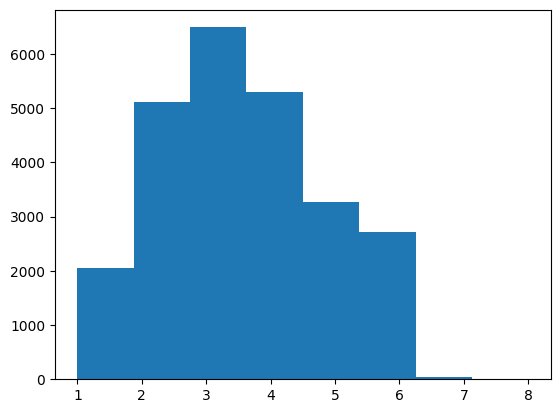

```python
transactions_df.apply('sum',axis = 1).hist(bins = 8, grid = False)
plt.show()
```

#### Top 10 Items by frequency

```python
item_counts = transactions_df.sum().sort_values(ascending=False)
item_freq_df = pd.DataFrame({
    'Product': item_counts.index,
    'Count': item_counts.values})
item_freq_df.head(10)
```

|  | Product | Count |
| --- | --- | --- |
| 0 | Fire TV Stick 4K Max | 953 |
| 1 | KitchenAid Stand Mixer | 934 |
| 2 | Maybelline Mascara | 909 |
| 3 | Ring Video Doorbell Pro | 902 |
| 4 | Adidas Ultraboost 22 | 899 |
| 5 | LEGO Star Wars Millennium Falcon | 893 |
| 6 | Nike Soccer Ball | 893 |
| 7 | Fitbit Charge 6 | 888 |
| 8 | Logitech MX Master 3S Mouse | 882 |
| 9 | Sony WH-1000XM5 Headphones | 881 |

#### Top 10 by Support

```python
item_freq_df['Support'] = item_freq_df['Count'] / len(transactions_df)
item_freq_df.head(10)
```

|  | Product | Count | Support |
| --- | --- | --- | --- |
| 0 | Fire TV Stick 4K Max | 953 | 0.03812 |
| 1 | KitchenAid Stand Mixer | 934 | 0.03736 |
| 2 | Maybelline Mascara | 909 | 0.03636 |
| 3 | Ring Video Doorbell Pro | 902 | 0.03608 |
| 4 | Adidas Ultraboost 22 | 899 | 0.03596 |
| 5 | LEGO Star Wars Millennium Falcon | 893 | 0.03572 |
| 6 | Nike Soccer Ball | 893 | 0.03572 |
| 7 | Fitbit Charge 6 | 888 | 0.03552 |
| 8 | Logitech MX Master 3S Mouse | 882 | 0.03528 |
| 9 | Sony WH-1000XM5 Headphones | 881 | 0.03524 |

### Frequent Itemsets

```python
frequent_itemsets = apriori(transactions_df,
                            min_support=0.001,
                            use_colnames=True)
```

### Association Rules

Retain rules with a lift greater than 1.05. Sort rules by lift, support and confidence.

```python
rules = association_rules(frequent_itemsets,
                          metric="lift",
                          min_threshold=1.05)
rules.sort_values(['lift','support','confidence'], ascending=[False,False,False]).head(10)
```

|  | antecedents | consequents | antecedent support | consequent support | support | confidence | lift | representativity | leverage | conviction | zhangs_metric | jaccard | certainty | kulczynski |
| --- | --- | --- | --- | --- | --- | --- | --- | --- | --- | --- | --- | --- | --- | --- |
| 920 | (Fossil Watch) | (iPhone 15 Pro Max) | 0.03352 | 0.03400 | 0.00316 | 0.094272 | 2.772708 | 1.0 | 0.002020 | 1.066545 | 0.661516 | 0.049099 | 0.062393 | 0.093607 |
| 921 | (iPhone 15 Pro Max) | (Fossil Watch) | 0.03400 | 0.03352 | 0.00316 | 0.092941 | 2.772708 | 1.0 | 0.002020 | 1.065510 | 0.661844 | 0.049099 | 0.061482 | 0.093607 |
| 1127 | (Instant Pot Duo 7-in-1) | (KitchenAid Stand Mixer) | 0.03376 | 0.03736 | 0.00332 | 0.098341 | 2.632260 | 1.0 | 0.002059 | 1.067632 | 0.641764 | 0.048968 | 0.063348 | 0.093603 |
| 1126 | (KitchenAid Stand Mixer) | (Instant Pot Duo 7-in-1) | 0.03736 | 0.03376 | 0.00332 | 0.088865 | 2.632260 | 1.0 | 0.002059 | 1.060480 | 0.644164 | 0.048968 | 0.057030 | 0.093603 |
| 1150 | (Instant Pot Duo 7-in-1) | (Vitamix 5200 Blender) | 0.03376 | 0.03508 | 0.00304 | 0.090047 | 2.566915 | 1.0 | 0.001856 | 1.060407 | 0.631755 | 0.046201 | 0.056966 | 0.088353 |
| 1151 | (Vitamix 5200 Blender) | (Instant Pot Duo 7-in-1) | 0.03508 | 0.03376 | 0.00304 | 0.086659 | 2.566915 | 1.0 | 0.001856 | 1.057918 | 0.632620 | 0.046201 | 0.054747 | 0.088353 |
| 943 | (Garmin Fenix 7 Watch) | (iPhone 15 Pro Max) | 0.03352 | 0.03400 | 0.00272 | 0.081146 | 2.386635 | 1.0 | 0.001580 | 1.051309 | 0.601151 | 0.041975 | 0.048805 | 0.080573 |
| 942 | (iPhone 15 Pro Max) | (Garmin Fenix 7 Watch) | 0.03400 | 0.03352 | 0.00272 | 0.080000 | 2.386635 | 1.0 | 0.001580 | 1.050522 | 0.601449 | 0.041975 | 0.048092 | 0.080573 |
| 587 | (Cuisinart Food Processor) | (Instant Pot Duo 7-in-1) | 0.03508 | 0.03376 | 0.00268 | 0.076397 | 2.262939 | 1.0 | 0.001496 | 1.046164 | 0.578387 | 0.040508 | 0.044127 | 0.077890 |
| 586 | (Instant Pot Duo 7-in-1) | (Cuisinart Food Processor) | 0.03376 | 0.03508 | 0.00268 | 0.079384 | 2.262939 | 1.0 | 0.001496 | 1.048124 | 0.577596 | 0.040508 | 0.045915 | 0.077890 |

## Summary

In this note, we examined market basket analysis first with a small toy dataset and then a moderate sized dataset of transactions on Amazon.

This file was generated using Python 3.13.5 on Windows 10 with the following libraries: matplotlib 3.10.3, mlxtend 0.23.4, numpy 2.3.1, pandas 2.3.0